# 06 Kiva Loans: Tree and Forest Models

Using a simple linear regression model of a log-transformed response, we were able to get our root MSE for the repayment rate on a loan to 3.48 USD per day. By stuffing 22 features into a multiple regression model, we brought the error down to 2.92 USD per day. However, this improvement in the error came at the cost of added model complexity, and it didn’t take care of the non-linearities in our data.

In this section, we explore whether tree-based models can do a better job of solving these problems – without falling victim to overfitting.

```r
library(jsonlite)
library(ggplot2)
library(tree)
library(randomForest)

loans.mb = jsonlite::fromJSON("loans_mb.json")
loans.mb = na.omit(loans.mb) # just to be safe

# trees need factors
loans.mb$location.country_code = as.factor(loans.mb$location.country_code)
loans.mb$continent = as.factor(loans.mb$continent)
loans.mb$sector = as.factor(loans.mb$sector)
```

## Decision trees

We’ll begin with a tree that has access to all features in our data set. The constructor in the `tree` library can’t accept factors with more than 32 levels, so we will use the continent variable instead of the country variable.

```r
# create test and training sets
set.seed(1)
mb.train.index = sample(dim(loans.mb)[1], dim(loans.mb)[1]/2)

loans.mb.train = loans.mb[mb.train.index, c(1, 4, 6, 7, 8, 12)]
loans.mb.test = loans.mb[-mb.train.index, c(1, 4, 6, 7, 8, 12)]

loans.mb.tree = tree(r.rate ~ ., loans.mb.train)
summary(loans.mb.tree)
```

```
##
## Regression tree:
## tree(formula = r.rate ~ ., data = loans.mb.train)
## Variables actually used in tree construction:
## [1] "terms.loan_amount" "continent"
## Number of terminal nodes:  6
## Residual mean deviance:  12.28 = 115600 / 9408
## Distribution of residuals:
##     Min.  1st Qu.   Median     Mean  3rd Qu.     Max.
## -18.8200  -1.6810  -0.4635   0.0000   1.3650  55.9000
```

From the summary, we can see that the tree used only two features: loan amount and continent. In a way, this result mirrors our finding in the multiple regression setting, namely that loan amount is the most important feature, followed by location-based features. At the same time, it is surprising that a more flexible method, which can be eager to overfit, didn’t fall prey to that vice here. Perhaps the conservative result of this liberal method is an indication that the other variables add only noise to a model of the repayment rate.

Since there are only two features at play and only six terminal nodes, we can plot this simple tree to see what it looks like:

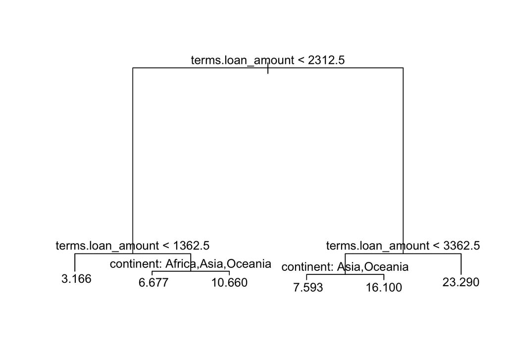

```r
plot(loans.mb.tree)
text(loans.mb.tree, pretty=0)
```

Given what we saw in our exploratory analysis, this trees makes a good deal of sense. In particular, the lower repayment rate for Asian countries on high-value loans is something that was evident in one of our plots.

We can use cross-validation to determine whether this is, in fact, the best possible decision tree.

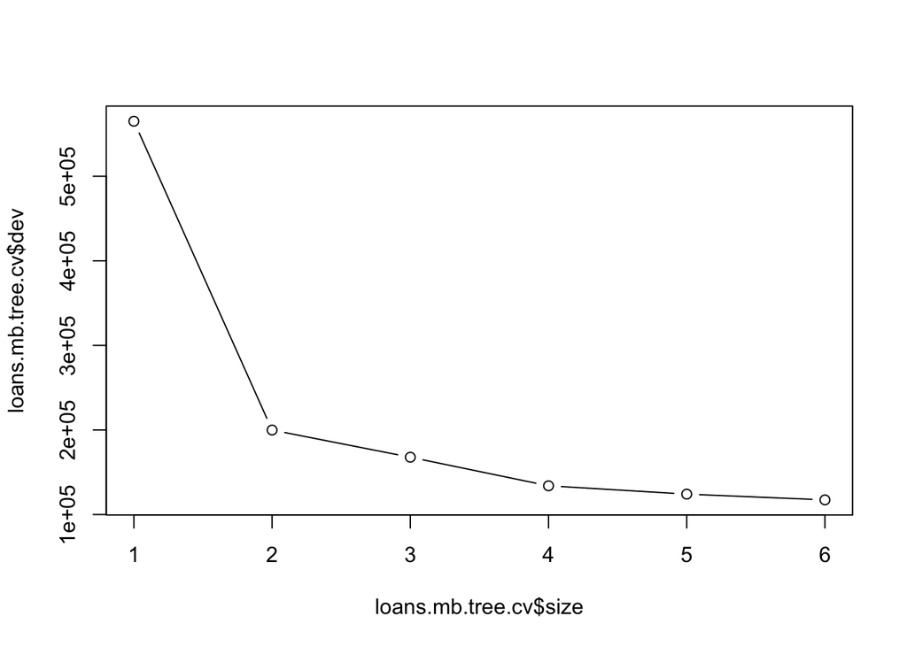

```r
loans.mb.tree.cv = cv.tree(loans.mb.tree)
plot(loans.mb.tree.cv$size, loans.mb.tree.cv$dev, type="b")
```

```r
loans.mb.tree.pred = predict(loans.mb.tree, newdata=loans.mb.test)
(mean((loans.mb.tree.pred - loans.mb.test$r.rate)^2))^.5
```

```
## [1] 3.637206
```

The error is 3.64, which is quite a bit worse than the multiple linear regression, and slightly worse than even the simple regression. What’s going on here? One hypothesis is that the repayment rate *is* fairly linear in the loan amount and the continent feature is too much of an aggregate view to be useful, so *on this feature set*, a regression is a more suitable choice than a tree. If we move to a higher-dimensional feature space, using country IVs instead of continent IVs, we might have reason to hope that a tree-based method – which can better exploit the non-linearities that lurk in this space – will outperform a linear method.

## Random forests

The `randomForest` package can handle factors with more than 32 levels, so we will set the `tree` package aside. With a 50-level factor, we are in danger of overfitting. Fortunately, avoiding overfitting is exactly what random forests were designed to do. By aggregating trees that are built from a random subset of the feature space, we can avoid constructing a model with a high variance. (A related approach is bagging, but because bagging produces correlated trees, the resulting aggregation may still have a high variance when predicting rates for out-of-bag observations.)

Let’s see how a random forest performs.

```r
# add country
loans.mb.train.rf = loans.mb[mb.train.index, c(1, 4, 6, 7, 8, 3)]
loans.mb.test.rf = loans.mb[-mb.train.index, c(1, 4, 6, 7, 8, 3)]

loans.mb.forest = randomForest(r.rate ~ ., data=loans.mb.train.rf,
                              mtry=3, importance=TRUE)

loans.mb.forest.pred = predict(loans.mb.forest, newdata=loans.mb.test.rf)
(mean((loans.mb.forest.pred - loans.mb.test.rf$r.rate)^2))^.5
```

```
## [1] 2.507441
```

This is our best result yet: an error of 2.51 USD per day. We can look at the variable importance measures in order to understand how the random forest weights different features.

```r
importance(loans.mb.forest)
```

```
##                         %IncMSE IncNodePurity
## sector                 24.27553      10735.73
## terms.loan_amount     160.29012     346343.91
## b.num                  25.68620      97618.09
## b.female               20.65627      10109.15
## location.country_code 251.78959      90931.57
```

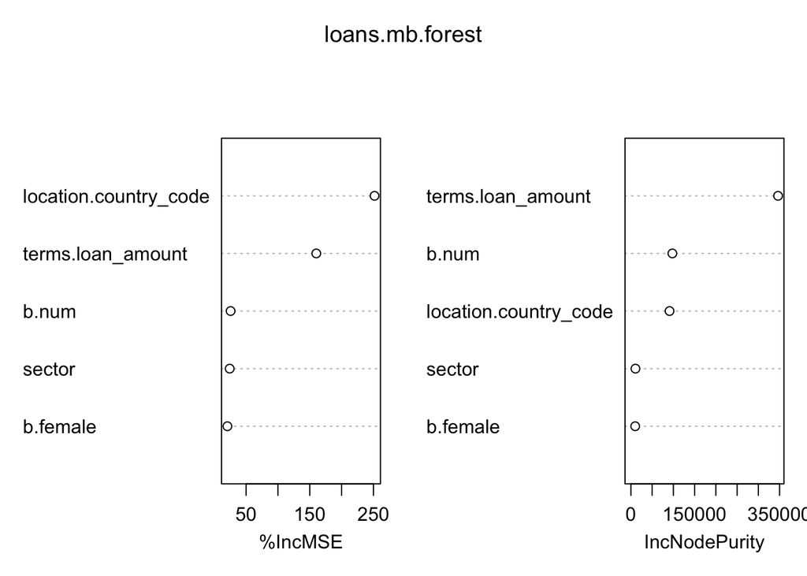

```r
varImpPlot(loans.mb.forest)
```

We see two different measures of importance: (1) the percent increase in MSE that occurs when a certain feature is *removed* from the model, and (2) the increase in node purity when that same feature is removed from the model. (Node purity is a similarity metric that essentially describes the variance of the response within a leaf of the aggregate tree.) Note that the loan amount is the feature that increases node purity the most, while country is the feature that reduces the test MSE the most. Evidently, both features are useful, and the random forest takes advantage of both.

Let’s look at a plot of the residuals so that we can get a feel for the shape of the error profile.

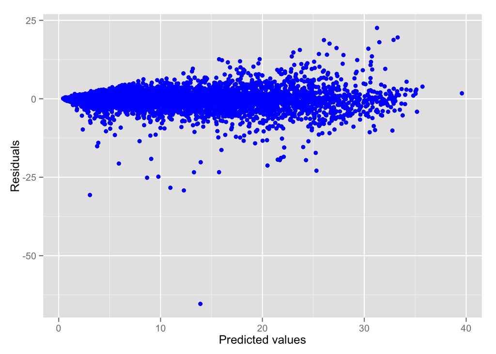

```r
rf.preds = unlist(as.list(loans.mb.forest.pred))
residuals = rf.preds - loans.mb.test.rf$r.rate
qplot(x=rf.preds, y=residuals) + geom_point(color="blue") +
  xlab("Predicted values") + ylab("Residuals")
```

The model is under-predicting the true repayment rate for a handful of loans. Doubtless, this handful of observations is a big source of the remaining error. As a quick experiment, what happens to the error if we remove loans (from both the training and the test set) whose repayment rates are in the upper decile?

```r
quantile(loans.mb$r.rate, seq(0, 1, 0.1))
```

```
##       0%      10%      20%      30%      40%      50%      60%      70%
##  0.03850  1.68604  2.27438  2.89815  3.67504  4.79310  6.43210  9.39878
##      80%      90%     100%
## 13.92734 20.35615 79.26440
```

```r
loans.mb.train.rf.low = loans.mb.train.rf[loans.mb.train.rf$r.rate<20,]
loans.mb.test.rf.low = loans.mb.test.rf[loans.mb.test.rf$r.rate<20,]

loans.mb.forest.low = randomForest(r.rate ~ ., data=loans.mb.train.rf.low,
                              mtry=3, importance=TRUE)

loans.mb.forest.pred.low = predict(loans.mb.forest.low,
                                   newdata=loans.mb.test.rf.low)
(mean((loans.mb.forest.pred.low - loans.mb.test.rf.low$r.rate)^2))^.5
```

```
## [1] 1.552234
```

The error drops to 1.55 USD per day. The residuals plot now looks like this:

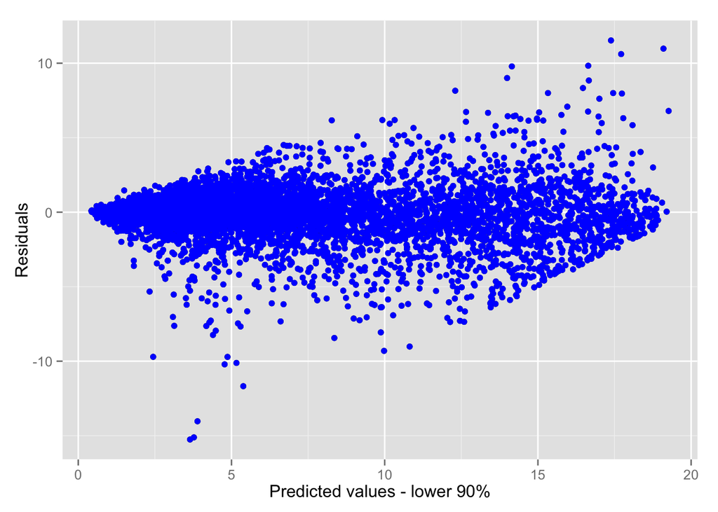

```r
rf.preds.low = unlist(as.list(loans.mb.forest.pred.low))
residuals.low = rf.preds.low - loans.mb.test.rf.low$r.rate
qplot(x=rf.preds.low, y=residuals.low) + geom_point(color="blue") +
  xlab("Predicted values - lower 90%") + ylab("Residuals")
```

This tells us that the model is doing fairly well for the main mass of loans, even as it struggles with loans with high repayment rates. We could try to characterize these loans to see whether we can create new features for our random forest to work with, but we will leave that task for later.

## Summary

Before considering how to extending the model to deal with these extremes, we will return to the single-borrower class, using the results from our analysis of the multiple-borrower class to speed things along.